# FunAqua R pipeline Technical validation document

05 December, 2025

# Technical validation and data visualization pipeline document

The following document includes R code which was used for data visualization and the generation of the majority of technical validation results under chapters “Sampling coverage” and “Sequencing depth”.

The pipeline also generates basic data overview given in the data paper.

it is strongly recommended that the user reads through the pipeline’s comments before running the document.

## 0. Generated files

Where ever possible, the code will generate required data tables inside their calling functions to reduce the amount of the data that is stored. However, in some cases it is more efficient to store the data outside of their functions.

As a general disclaimer, the recommended minimum amount of RAM for running the script is 32GB, as some of the functions, such as the rarefaction curve calculations, are rather resource-heavy.

The following files will be generated, but not retained, throughout the code’s run for various purposes:

- **Sample metadata tables as data.frame objects**
  - metadata - sample metadata corresponding to all samples
  - metadatased - sample metadata for sediments
  - metadatawat - sample metadata for filtered water samples
- **OTU tables given as data.frame objects**
  - eukotu - non-fungal eukaryotes OTU table
  - fungiotu - fungal OTU table
  - eukotused - non-fungal eukaryotes OTU table for OTUs detected in sediments
  - fungiotused - fungal OTU table for OTUs detected in sediments
  - eukotuwat - non-fungal eukaryotes OTU table for OTUs detected in water samples
  - fungiotuwat - fungal OTU table for OTUs detected in water samples
- **Taxonomy tables given as data.frame objects**
  - euktax - non-fungal eukaryotes taxonomy table
  - fungitax - fungal taxonomy table
  - euktaxsed - non-fungal eukaryotes taxonomy table for OTUs found in sediments
  - fungitaxsed - fungal taxonomy table for OTUs found in sediments
  - euktaxwat - non-fungal eukaryotes taxonomy table for OTUs found in water samples
  - fungitaxwat - fungal taxonomy table for OTUs found in water samples
  - combinedtax - combined taxonomy table including both fungal and non-fungal OTUs
- **Phyloseq objects**
  - fungiphyseq - phyloseq object pertaining to fungal OTU data
  - eukphyseq - phyloseq object pertaining to non-fungal OTU data
- **Objects generated for data visualization purposes**
  - specaccumsed - sediment species (OTU) accumulation data for accumulation curve plotting
  - specaccumwat - filtered water species (OTU) accumulation data for accumulation curve plotting
- **Data for Good’s index calculations**
  - goodsindex - data frame including Good’s coverage index values
  - eukseqtotal - vector used for storing the number of non-fungal sequences detected in samples
  - euksingletons - vector used for storing the number of non-fungal singletons detected in samples
  - fungalsingeltons - vector used for storing the number of fungal singletons detected in samples
  - fungalseqtotal - vector used for storing the number of fungal sequences detected in samples
  - i - used for iterating through the Good’s coverage index calculation cycle

## 1. Preparation steps

### 1.1 Importing required packages

Before running the pipeline, confirm that the following packages are installed.

```r
library(dplyr) # Required for basic data manipulation.
library(tidyverse) # Required for basic data manipulation and graph generation.
library(ggpattern) # Required for producing side-by-side bar charts with a patterned aesthetic.
library(phyloseq) # Required for easier community data manipulation.
library(DT) # Required for producing interactive tables.
library(kableExtra) # Required for customizing interactive tables.
library(vegan) # Required for rarefaction curves.
library(sf) # Required for drawing the map depicting sampling plots.
library(rworldmap) # Required for drawing the map depicting sampling plots.
library(rnaturalearth) # Required for drawing the map depicting sampling plots.
library(leaflet) # Required for generating interactive maps.
library(ggpubr) # Required for combining the heatmap plots together.
```

### 1.2 Importing required files

In order for the file importing to run smoothly, confirm that the taxonomy, OTU and metadata files are in your working directory.  
If you are running both the .Rmd file and the provided .R script, these working directories may be different, as the working directory for R Markdown is typically located elsewhere.

### 1.3 Validation of the imported files

The next part of the code will check if the files were imported correctly by comparing column and row names of the imported files. Columns in the OTU tables are named after the sample names, while the rows represent OTUs. Row names of the metadata table are named after samples. Lastly, row names of the taxonomy table correspond to OTU names.

If all of the data was imported correctly, all of the functions return “TRUE”.

```r
# Checking if column names i.e sample names of the fungal OTU table match the row names of the metadata table.
# If the column and row names match it returns:"TRUE", which means that the files were imported correctly.
cat("The column names of the fungal OTU table match the row names of the metadata table: ",
            identical(colnames(fungiotu), rownames(metadata)), "\n")
```

```
## The column names of the fungal OTU table match the row names of the metadata table:  TRUE
```

```r
# Checking if column names i.e sample names of the non-fungal OTU table match the row names of the metadata table
# If the column and row names match it returns:"TRUE", which means that the files were imported correctly.
cat("The column names of the non-fungal OTU table match the row names of the metadata table: ",
  identical(colnames(eukotu), rownames(metadata)), "\n")
```

```
## The column names of the non-fungal OTU table match the row names of the metadata table:  TRUE
```

```r
# Checking if the row names of the fungal OTU table and taxonomy table match
# If the row names of the two tables match it returns:"TRUE", which means that the files were imported correctly.
cat("The row names of the fungal OTU table match the row names of the fungal taxonomy table: ",
  identical(rownames(fungiotu), rownames(fungitax)), "\n")
```

```
## The row names of the fungal OTU table match the row names of the fungal taxonomy table:  TRUE
```

```r
# Checking if the row names of the non-fungal OTU table and taxonomy table match
# If the row names of the two tables match it returns:"TRUE", which means that the files were imported correctly.
cat("The row names of the non-fungal OTU table match the row names of the non-fungal taxonomy table: ",
  identical(rownames(eukotu), rownames(euktax)), "\n")
```

```
## The row names of the non-fungal OTU table match the row names of the non-fungal taxonomy table:  TRUE
```

Next, the code will confirm that:  
1) there are no un-represented OTUs in either OTU table i.e OTUs not detected in any sample;  
2) there are no samples that do not have any OTUs.

```r
# Checking if there are any rows (OTUs) in the non-fungal OTU table that have a sum of row values (occurrences) of 0 i.e the OTU is not represented by any sample.
# If there are no unrepresented OTUs, it returns: "FALSE".
cat("There are unrepresented non-fungal OTUs: ", any(rowSums(eukotu) == 0), "\n")
```

```
## There are unrepresented non-fungal OTUs:  FALSE
```

```r
# Checking if there are any rows (OTUs) in the fungal OTU table that have a sum of row values (occurrences) of 0 i.e the OTU is not represented by any sample.
# If there are no unrepresented OTUs, it returns: "FALSE".
cat("There are unrepresented fungal OTUs: ", any(rowSums(fungiotu) == 0), "\n")
```

```
## There are unrepresented fungal OTUs:  FALSE
```

```r
# Checking if there are any columns (samples) in the OTU table that have a sum of column values of 0 i.e the sample has no OTUs.
# The code checks both the fungal and non-fungal OTUs, as some samples have OTUs from one group, but not the other.
# If there are no samples with no OTUs, it returns: "FALSE".
cat("There are samples without any detected OTUs: ", any(colSums(rbind(eukotu, fungiotu)) == 0), "\n")
```

```
## There are samples without any detected OTUs:  FALSE
```

### 1.4 Addition of OTU count and sequence numbers in the metadata table for each sample

The following code section will add 6 columns to the metadata table:  
1) fungi_otu_count - number of fungal OTUs detected in a sample;  
2) fungi_seq_count - number of fungal sequences detected in a sample;  
3) euk_otu_count - number of non-fungal eukaryotic OTUs detected in a sample;  
4) euk_seq_count - number of non-fungal sequences detected in a sample;  
5) total_otu_count - total number of OTUs detected in a sample;  
6) total_seq_count - total number of sequences detected in a sample.

```r
# Adding column fungi_otu_count to the metadata table which includes the number of unique OTUs detected in samples.
metadata$fungi_otu_count <- apply(fungiotu, 2, function(x) sum(x > 0))

# Adding column fungi_seq_count to the metadata table which includes the number of fungal sequences detected in samples.
metadata$fungi_seq_count <- colSums(fungiotu)

# Adding column euk_otu_count to the metadata table which includes the number of non-fungal OTUs detected in samples.
metadata$euk_otu_count <-apply(eukotu, 2, function(x) sum(x > 0))

# Adding column fungi_seq_count to the metadata table which includes the number of non-fungal sequences detected in samples.
metadata$euk_seq_count <- colSums(eukotu)

# Adding column total_otu_count to the metadata table which includes the total number of OTUs detected in samples.
metadata$total_otu_count <- metadata$fungi_otu_count + metadata$euk_otu_count

# Adding column total_seq_count to the metadata table which includes the total number of OTUs detected in samples.
metadata$total_seq_count <- metadata$fungi_seq_count + metadata$euk_seq_count
```

### 1.5 Construction of phyloseq objects

Phyloseq objects generated from the imported datasets make some processes of the data overview process more efficient.

```r
# Generating the phyloseq object for fungal data.
# fungiotu and fungitax are converted into matrices before being used as input for otu_table() and tax_table
fungiphyseq = phyloseq(
  otu_table(as(fungiotu,"matrix"), taxa_are_rows = TRUE),
  tax_table(as(fungitax, "matrix")),
  sample_data(metadata))

# Generating the phyloseq object for non-fungal eukaryotes.
# eukotu and euktax are converted into matrices before being used as input for otu_table() and tax_table().
eukphyseq = phyloseq(otu_table(as(eukotu,"matrix"), taxa_are_rows = TRUE),
                     tax_table(as(euktax, "matrix")),
                     sample_data(metadata))
```

### 1.6 Subsetting data based on sample type

The metadata, taxonomy and OTU tables are subset into tables based on sample type.

```r
# Subsetting the sediment data from the metadata table.
metadatased <- metadata %>%
  filter(sample_source == "sediment")

# Subsetting the filtered water data from the metadata table.
metadatawat<- metadata %>%
  filter(sample_source == "water")

# Creating sediment and water sample specific fungal taxonomy and OTU tables.

# Subsetting the fungal OTU data to only include OTU data from sediment samples.
fungiotused <- fungiotu[c(row.names(metadatased))]

# Removing the rows (OTUs) which sum to 0 and are thus not present in any sediment samples.
fungiotused <- fungiotused[rowSums(fungiotused[])>0,]

# Subsetting the fungal OTU data to only include OTU data from water samples.
fungiotuwat<- fungiotu[c(row.names(metadatawat))]

# Removing the rows (OTUs) which sum to 0 and are thus not present in any water samples.
fungiotuwat <- fungiotuwat[rowSums(fungiotuwat[])>0,]

# Subsetting the fungal taxonomy table to only include taxonomy data from sediment samples.
fungitaxsed <- fungitax[c(row.names(fungiotused)),]

# Subsetting the fungal taxonomy table to only include taxonomy data from  water samples.
fungitaxwat <- fungitax[c(row.names(fungiotuwat)),]

# Creating sediment and water sample specific non-fungal taxonomy and OTU tables.

# Subsetting the non-fungal OTU data to only include OTU data from sediment samples.
eukotused <- eukotu[c(row.names(metadatased))]

# Removing the rows (OTUs) which sum to 0 and are thus not present in any sediment samples.
eukotused <- eukotused[rowSums(eukotused[])>0,]

# Subsetting the non-fungal OTU data to only include OTU data from water samples.
eukotuwat<- eukotu[c(row.names(metadatawat))]

# Removing the rows (OTUs) which sum to 0 and are thus not present in any water samples.
eukotuwat <- eukotuwat[rowSums(eukotuwat[])>0,]

# Subsetting the fungal taxonomy table to only include taxonomy data from sediment samples.
euktaxsed <- euktax[c(row.names(eukotused)),]

# Subsetting the fungal taxonomy table to only include taxonomy data from  water samples.
euktaxwat <- euktax[c(row.names(eukotuwat)),]
```

## 2. Dataset overview

The following part of the code will give an overview of the data included in the datasets.

### 2.1 general overview

This section includes a general overview of the number of samples collected.

```r
# Returns the number of samples represented by the database
cat("The total number of samples in the database: ", nrow(metadata), "\n")
```

```
## The total number of samples in the database:  2375
```

```r
# Returns the number of sediment and filtered water samples represented by the database
cat("The total number of sediment samples in the database: ", table(metadata$sample_source)[1],
    "\nThe total number of filtered water samples in the database: ", table(metadata$sample_source)[2], "\n")
```

```
## The total number of sediment samples in the database:  1076
## The total number of filtered water samples in the database:  1299
```

```r
# Returns the number of unique sampling plots
cat("The total number of sampling plots:",
            as.numeric((metadata %>%
              summarise(count = n_distinct(plot_name)))), "\n")
```

```
## The total number of sampling plots: 1452
```

```r
# Returns the number of sampling plots that have both a sediment and filtered water sample
cat("The number of sampling plots that have both a sediment and filtered water sample:",
  nrow(metadata %>%
  group_by(plot_name) %>%
  filter(all(c("sediment", "water") %in% sample_source)) %>%
  summarise(count = n_distinct(plot_name))), "\n")
```

```
## The number of sampling plots that have both a sediment and filtered water sample: 920
```

### 2.2 Geographic overview

#### 2.2.1 Countries

This section includes an overview of the countries sampled for the database.

```r
# Returns the number of countries represented by the database
cat("The total number of countries represented by the database:",
            as.numeric(metadata %>%
              filter(!(country == "Unspecified")) %>%
              summarise(count = n_distinct(country))), "\n")
```

```
## The total number of countries represented by the database: 87
```

The following code generates an interactive table which includes information on the sampling coverage of each country, including how many samples of either type were collected from each country together with the total number of samples.

```r
# Generates an interactive table that shows the number of samples collected from each country.
# Row names (row numbers) cannot be hidden for this interactive table as the produced table is too large.
# The table fails to materialize when the row names are hidden.

DT::datatable(metadata %>% # Generating the input table for the interactive table.
                 group_by(country, sample_source) %>%
                 summarise(count = n(), .groups = "drop") %>% # Generating sample count numbers.
                 # Converting the data from long format to wide format.
                 pivot_wider(names_from = sample_source,  # Retrieving the column names based on the sample_source column.
                             values_from = count, # Retrieving the cell values from the previously generated count data.
                             values_fill = 0) %>% # If a sample count is missing (NA), it is replaced with 0.
                 rename( # Renaming the columns for visual clarity purposes.
                   "Number of Sediment Samples" = sediment,
                   "Number of Water Samples" = water) %>%
                mutate(`Total Number of Samples` = `Number of Sediment Samples` +  # Generating a column that shows the combined number of samples.
                         `Number of Water Samples`),
               # The generated table shows 10 rows at a time.
               # The table is ordered in descending order according to the total number of samples collected.
                options = list(pageLength = 10, order = list(4, "desc")))
```

|  | country | Number of Water Samples | Number of Sediment Samples | Total Number of Samples |
| --- | --- | --- | --- | --- |
| 1 | Albania | 4 | 0 | 4 |
| 2 | Antarctica | 95 | 5 | 100 |
| 3 | Australia | 31 | 33 | 64 |
| 4 | Austria | 2 | 2 | 4 |
| 5 | Bangladesh | 0 | 2 | 2 |
| 6 | Belgium | 1 | 1 | 2 |
| 7 | Benin | 3 | 3 | 6 |
| 8 | Bolivia | 3 | 4 | 7 |
| 9 | Bosnia and Herzegovina | 1 | 1 | 2 |
| 10 | Brazil | 18 | 23 | 41 |

[output cut: 78 more lines]

The next part of this section generates a static map of the sampling points.

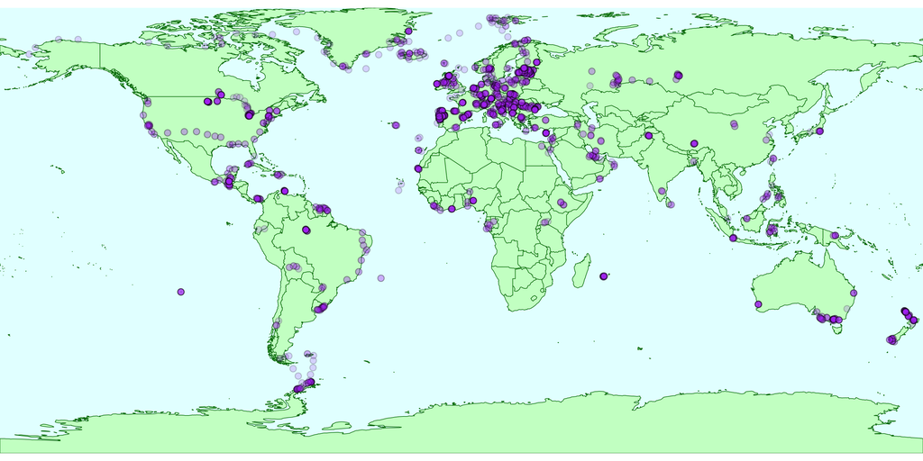

```r
ggplot() +
  # Drawing the base map without any points.
  geom_sf(data = (ne_countries(scale = "medium", returnclass = "sf")), fill = "darkseagreen1", color = "darkgreen") +

  # Adding the sampling points of samples with coordinates preserved onto the map
  geom_sf(data = (st_as_sf((metadata %>% filter(!is.na(lat) & !is.na(long))), coords = c("long", "lat"),
                           crs = 4326)),
          shape = 21, fill = "purple", color ="black", stroke = 0.5, size = 2, alpha = 0.2) +
  theme_void() +
  theme(panel.background = element_rect(fill = "lightcyan"))+
  coord_sf(expand = FALSE)
```

The last code of this section returns an interactive map where each point on the map represents a sampling plot. Since the database includes a lot of samples, the map will be rather slow to navigate.

**Click here to view the interactive map**

```r
leaflet() %>%
  addTiles() %>%
  addMarkers(
    lng = metadata$long, lat = metadata$lat,
    popup = metadata$plot_name)
```

[interactive chart not shown]

#### 2.2.2 Continents

This section includes an overview of the sampling coverage across continents.

The following code generates a table which includes information about sampling coverage across continents, including:

1. The number of sediment samples collected from each continent
2. The number of filtered water samples collected from each continent
3. The total number of samples collected from each continent
4. Each continent’s contribution to the total sediment sample count (%)
5. Each continent’s contribution to the total filtered water sample count (%)
6. The overall proportion (%) of samples originating from each continent

```r
# Generates an interactive table that shows the number of samples collected from each continent
DT::datatable(metadata %>% # Genrating the input table for the interactive table.
  count(continent, sample_source) %>% # Generating sample count numbers.
  pivot_wider(names_from = sample_source, values_from = n, values_fill = 0) %>% # Converting the table from long format to wide format.
  mutate( # Generating columns showing:
    total = sediment + water, # The total number of samples;
    `sediment %` = round(sediment / sum(sediment) * 100, 2), # The proportion of sediment samples from the continents relative to all sediment samples.
    `water %` = round(water / sum(water) * 100, 2), # The proportion of filtered water samples from the continents relative to all filtered water samples.
    `total %` = round(total / sum(total) * 100, 2)), # The combined proportion of samples from the continents relative to all samples.
  rownames = FALSE,  #Hiding the row names i.e row numbers.
  options = list(order = list(4, "desc"))) # The table is sorted in a descending order.
```

| continent | sediment | water | total | sediment % | water % | total % |
| --- | --- | --- | --- | --- | --- | --- |
| Africa | 36 | 60 | 96 | 3.35 | 4.62 | 4.04 |
| Antarctica | 5 | 95 | 100 | 0.46 | 7.31 | 4.21 |
| Asia | 103 | 84 | 187 | 9.57 | 6.47 | 7.87 |
| Europe | 626 | 701 | 1327 | 58.18 | 53.96 | 55.87 |
| North America | 152 | 214 | 366 | 14.13 | 16.47 | 15.41 |
| Oceania | 82 | 84 | 166 | 7.62 | 6.47 | 6.99 |
| South America | 72 | 61 | 133 | 6.69 | 4.7 | 5.6 |

Additionally, the next section of code will generate a side-by-side bar chart depicting the number of samples collected from each continent.

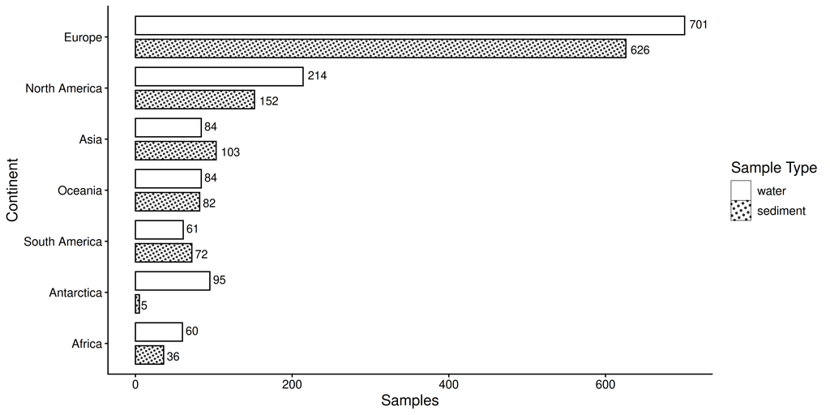

```r
ggplot(
  # Generating a contingency table with the variables sample_source and continent with table() as the input data.frame object for plotting.
  data.frame(table(metadata$sample_source, metadata$continent)),
  # x-axis will depict Freq i.e the number of samples.
  # y-axis will depict Var2 (continent) reordered in descending order according to the number of samples collected.
       aes(x = Freq, y = reorder(Var2,Freq), pattern = Var1))+
  # Adjusting the aesthetics of the generated bars.
  geom_col_pattern(fill = "white", position = position_dodge2(width = 0.5,padding = 0.2), pattern_density = 0.3,
                   pattern_fill = "black", pattern_spacing = 0.01, colour = "black")+
  # Manually specifying the pattern fill types of the sample types.
  scale_pattern_manual(values =  c("water" = "none", "sediment" = 'circle'),
                       breaks = c("water", "sediment"))+
  # Adding the number of collected samples next to the bars.
  geom_text(aes(x = Freq, y = Var2, label = Freq, group = Var1),
            position = position_dodge(width = 1), vjust = 0.5, hjust = -0.25, size = 3.5)+
  # Adding custom labels to the axes and the legend.
  labs(x = "Samples", y = "Continent", pattern = "Sample Type")+
  # Setting the ggplot theme to classic.
  theme_classic()+
  # Changing the size of text.
  theme(text = element_text(size=13))
```

### 2.3 Biome overview

#### 2.3.1 General overview of biomes

This section of the pipeline gives an overview of the biome sampling coverage.

```r
# Returns the total number of biomes represented by the database
cat("The total number of biomes represented by the database, disregarding unknown biomes:",
            as.numeric(metadata %>%
              filter(!(biome == "aquatic: other")) %>%
              summarise(count = n_distinct(biome))), "\n")
```

```
## The total number of biomes represented by the database, disregarding unknown biomes: 10
```

The following code generates a table which includes information about sampling coverage across biomes, including:

1. The number of sediment samples collected from each biome
2. The number of filtered water samples collected from each biome
3. The total number of samples collected from each biome
4. Each biome’s contribution to the total sediment sample count (%)
5. Each biome’s contribution to the total filtered water sample count (%)
6. The overall proportion (%) of samples originating from each biome

```r
# Generates a table that shows the number of samples collected from each biome
knitr::kable(metadata %>%
               mutate(biome = gsub("^aquatic:\\s*", "", biome)) %>%
               count(biome, sample_source) %>% # Calculating sample count data
               pivot_wider(names_from = sample_source, values_from = n, values_fill = 0) %>% # Converting the table from long format to wide format
               mutate(
                 total = sediment + water, # The total number of samples collected from the biomes.
                 `sediment %` = round(sediment / sum(sediment) * 100, 2), # The proportion of the sediment samples from the biomes relative to all sediment samples.
                 `water %` = round(water / sum(water) * 100, 2), # The proportion of filtered water samples from the biomes relative to all filtered water samples.
                 `total %` = round(total / sum(total) * 100, 2))) %>% # The combined proportion of samples from the biomes relative to all samples.
  kable_classic() %>%
  kable_styling(full_width = FALSE)
```

| biome | sediment | water | total | sediment % | water % | total % |
| --- | --- | --- | --- | --- | --- | --- |
| brackish lake biome | 5 | 5 | 10 | 0.46 | 0.38 | 0.42 |
| brackish marine biome | 72 | 85 | 157 | 6.69 | 6.54 | 6.61 |
| freshwater lake biome | 504 | 543 | 1047 | 46.84 | 41.80 | 44.08 |
| freshwater river biome | 394 | 374 | 768 | 36.62 | 28.79 | 32.34 |
| freshwater spring biome | 2 | 1 | 3 | 0.19 | 0.08 | 0.13 |
| mangroves | 9 | 7 | 16 | 0.84 | 0.54 | 0.67 |
| other | 3 | 6 | 9 | 0.28 | 0.46 | 0.38 |
| saltmarsh biome | 5 | 4 | 9 | 0.46 | 0.31 | 0.38 |
| saltwater lake biome | 5 | 7 | 12 | 0.46 | 0.54 | 0.51 |
| saltwater marine biome | 73 | 264 | 337 | 6.78 | 20.32 | 14.19 |
| thermal spring biome | 4 | 3 | 7 | 0.37 | 0.23 | 0.29 |

Additionally, the next section of code will generate a side-by-side bar chart depicting the number of samples collected from each biome.

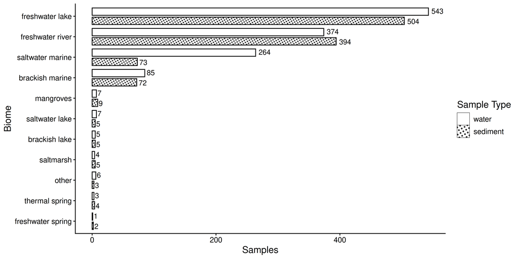

```r
# Generates a side-by-side bar chart that depicts the number of samples collected from each biome

ggplot(
  # Generating a contingency table with the variables sample_source and biome with table() as the input data.frame object for plotting.
  data.frame(table(metadata$sample_source, metadata$biome)),
  # x-axis will depict Freq i.e the number of samples.
  # y-axis will depict Var2 (biome) reordered in descending order according to the number of samples collected.
       aes(x = Freq, y = reorder(Var2, Freq), pattern = Var1))+
  # Removing the substring "aquatic: " from the biome names while graphing.
  scale_y_discrete(labels = function(y) {
    y <- gsub("aquatic: ", "", y)
    gsub(" biome", "", y)
  })+
  # Adjusting the aesthetics of the generated bars.
  geom_col_pattern(fill = "white",position = position_dodge2(width = 0.5, padding = 0.2), pattern_density = 0.3,
                   pattern_fill = "black", pattern_spacing = 0.01, colour = "black")+
  # Manually specifying the pattern fill types of the sample types.
  scale_pattern_manual(values=  c("water" = "none", "sediment" = 'circle'),
                       breaks = c("water", "sediment"))+
  # Adding the number of collected samples next to the bars.
  geom_text(aes(x = Freq, y = Var2, label = Freq, group = Var1),
            position = position_dodge(width = 1), vjust = 0.5, hjust = -0.25, size = 3.5)+
  # Adding custom labels to the axes and the legend.
  labs(x = "Samples", y = "Biome", pattern = "Sample Type")+
  # Setting the ggplot theme to classic
  theme_classic()+
  # Adjusting the text size.
  theme(text = element_text(size = 13))
```

#### 2.3.2 Biome coverage across continents

This section of the pipeline produces heat maps that depict the distribution of samples from each biome collected on each continent.

The code will return the following warning after running: “Warning: removed XX rows containing missing values or values outside the scale range (`geom_text()`)”

This is expected behaviour, as some of the table values are NAs because not all biomes are represented on all continents, thus those NA values need to be dropped.

The first heat map depicts the combined distribution of both sediment and water samples collected from each biome across all continents.

```
## Warning: Removed 33 rows containing missing values or values outside the scale range
## (`geom_text()`).
```

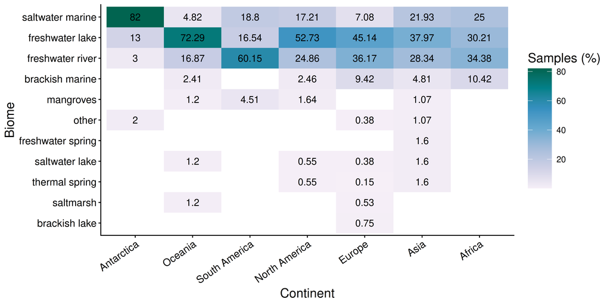

```r
ggplot(data = { # First step: generating the table from which the frequency data is extracted from.
  dataframe <- data.frame(table( # table() generates a contingency table needed for plotting
     metadata$biome, # Extracting the biome variable as the first contingency table variable.
    metadata$continent # Extracting the continent variable as the first contingency table variable.
  ))
  # Second step: calculating the abundance of samples collected from each biome on each continent in percentages.
  dataframe <- dataframe %>%
    group_by(Var2) %>% # The dataframe is temporarily grouped by Var2 (continent).
    mutate(per = (Freq / sum(Freq)) * 100, # Generating a new variable per, which shows how many % each biome's sample makes up of the continent's samples.
           # If the biome frequency is 0, the percentage value is changed to NA for that row.
           # This is done so that the na.value field can be used for scale_fill_distiller() function.
           per = ifelse(Freq == 0, NA, per)) %>%
    ungroup() #The dataframe is ungrouped.
  dataframe},
  # Mapping aesthetics with aes().
  # x-axis will depict Var2 (continents).
  # y-axis will depict Var1 (biomes).
  # y = reorder(Var1, Freq) - the y axis is reordered in a descending order according to the biome frequency.
  # Fill = per - the colour of the heatmap cells is determined according to the per (percentage) variable.
  aes(
    x = reorder(Var2, per, FUN = function(z) -max(z, na.rm = TRUE)),
    y = reorder(Var1, per, FUN = function(z) -max(z, na.rm = TRUE)),
    fill = per)) +
  geom_tile() + # Initializes the heatmap base with tile based aesthetics.
  # Scale_fill_distiller() - customization of the heatmap colour scale.
  # name = "Samples (%)" - setting the name of the legend as "Samples (%)"
  # palette = "PuBuGn" - the colour gradient flows from purple to blue to green.
  # na.value = "transparent" - tiles of biomes not represented on the continent will be transparent.
  # direction = 1 - putting the sequence of colours in reverse. Defaults to direction = -1.
  scale_fill_distiller(name = "Samples (%)", palette = "PuBuGn", na.value="transparent",
                       direction = 1) +
  # Replacing the substring "aquatic: " with "" on the y-axis for clarity purposes.
  scale_y_discrete(limits = rev,labels = function(y) {
    y <- gsub("aquatic: ", "", y)
    gsub(" biome", "", y)
  })+
  # Setting the ggplot theme as classic.
  theme_classic() +
  # Adjusting aesthetical parameters pertaining to the legend and font size.
  theme(legend.position = "right", legend.direction = "vertical",
        legend.title = element_text(size = 15), legend.key.size = unit(1,"cm"),
        legend.text = element_text(size = 10),
        text = element_text(size = 15),
        axis.text.x = element_text(angle = 35, hjust = 1)) +
  # Labelling the heatmap tiles with the percentage values of each biome.
  geom_text(aes(label = round(per, 2)),color="black", size = 4)+
  # Setting the axes labels.
  labs(y = "Biome", x = "Continent")
```

The second heat map depicts the separate distribution of sediment and filtered samples collected from each biome across all continents.

```r
# Generates a heat map that depicts the distribution of sediment samples collected from each biome on each continent

ggarrange((ggplot(data = { # First step: generating the table from which the frequency data is extracted from.
  dataframe <- data.frame(table( # table() generates a contingency table of a filtered version of the metadata table.
    # Before the variables are extracted for the contingency table, the data is filtered to only include rows representing sediment samples.
    (metadata %>% filter(sample_source == "sediment"))$biome, # Extracting the biome variable as the first contingency table variable.
    (metadata %>% filter(sample_source == "sediment"))$continent # Extracting the continent variable as the first contingency table variable.
  ))
  # Second step: calculating the abundance of samples collected from each biome on each continent in percentages.
  dataframe <- dataframe %>%
    group_by(Var2) %>% # The dataframe is temporarily grouped by Var2 (continent).
    mutate(per = (Freq / sum(Freq)) * 100, # Generating a new variable per, which shows how many % each biome's sample makes up of the continent's samples.
           # If the biome frequency is 0, the percentage value is changed to NA for that row.
           # This is done so that the na.value field can be used for scale_fill_distiller() function.
           per = ifelse(Freq == 0, NA, per)) %>%
    ungroup() #The dataframe is ungrouped.
  dataframe},
  # Mapping aesthetics with aes().
  # x-axis will depict Var2 (continents).
  # y-axis will depict Var1 (biomes).
  # y = reorder(Var1, Freq) - the y axis is reordered in a descending order according to the biome frequency.
  # Fill = per - the colour of the heatmap cells is determined according to the per (percentage) variable.
  aes(
    x = reorder(Var2, per, FUN = function(z) -max(z, na.rm = TRUE)),
    y = reorder(Var1, per, FUN = function(z) -max(z, na.rm = TRUE)),
    fill = per))  +
  geom_tile() + #Initializes the heatmap base with tile based aesthetics.
  # Scale_fill_distiller() - customization of the heatmap colour scale.
  # name = "Samples (%)" - setting the name of the legend as "Samples (%)"
  # palette = "PuBuGn" - the colour gradient flows from purple to blue to green.
  # na.value = "transparent" - tiles of biomes not represented on the continent will be transparent.
  # direction = 1 - putting the sequence of colours in reverse. Defaults to direction = -1.
  scale_fill_distiller(name = "Samples (%)", palette = "PuBuGn", na.value="transparent",
                       direction = 1, limits = c(0,80)) +
  # Replacing the substring "aquatic: " with "" on the y-axis for clarity purposes.
  scale_y_discrete(limits = rev, labels = function(y) {
    y <- gsub("aquatic: ", "", y)
    gsub(" biome", "", y)
  })+
  # Setting the ggplot theme as classic.
  theme_classic() +
  # Adjusting aesthetical parameters pertaining to the legend and font size.
  theme(legend.position = "right", legend.direction = "vertical",
        legend.title = element_text(size = 15), legend.key.size = unit(1,"cm"),
        legend.text = element_text(size = 10),
        text = element_text(size = 15),
        axis.text.x = element_text(angle = 35, hjust = 1)) +
  # Labelling the heatmap tiles with the percentage values of each biome.
  geom_text(aes(label = round(per, 2)),color="black", size = 4)+
  # Setting the axes labels.
  labs(y = "Biome", x = "Continent")),
  (# Generates a heat map that depicts the distribution of filtered samples collected from each biome on each continent.

ggplot(data = { # First step: generating the table from which the frequency data is extracted from.
  dataframe <- data.frame(table( # table() generates a contingency table of a filtered version of the metadata table.
    # Before the variables are extracted for the contingency table, the data is filtered to only include rows representing filtered water samples.
    (metadata %>% filter(sample_source == "water"))$biome, # Extracting the biome variable as the first contingency table variable.
    (metadata %>% filter(sample_source == "water"))$continent # Extracting the continent variable as the first contingency table variable.
  ))
  # Second step: calculating the abundance of samples collected from each biome on each continent in percentages.
  dataframe <- dataframe %>%
    group_by(Var2) %>% # The dataframe is temporarily grouped by Var2 (continent).
    mutate(per = (Freq / sum(Freq)) * 100, # Generating a new variable per, which shows how many % each biome's sample makes up of the continent's samples.
           # If the biome frequency is 0, the percentage value is changed to NA for that row.
           # This is done so that the na.value field can be used for scale_fill_distiller() function.
           per = ifelse(Freq == 0, NA, per)) %>%
    ungroup() # The dataframe is ungrouped.
  dataframe},
  # Mapping aesthetics with aes().
  # x-axis will depict Var2 (continents).
  # y-axis will depict Var1 (biomes).
  # y = reorder(Var1, Freq) - the y axis is reordered in a descending order according to the biome frequency.
  # Fill = per - the colour of the heatmap cells is determined according to the per (percentage) variable.
  aes(
    x = reorder(Var2, per, FUN = function(z) -max(z, na.rm = TRUE)),
    y = reorder(Var1, per, FUN = function(z) -max(z, na.rm = TRUE)),
    fill = per)) +
  geom_tile() + # Initializes the heatmap base with tile based aesthetics.
  # Scale_fill_distiller() - customization of the heatmap colour scale.
  # name = "Samples (%)" - setting the name of the legend as "Samples (%)"
  # palette = "PuBuGn" - the colour gradient flows from purple to blue to green.
  # na.value = "transparent" - tiles of biomes not represented on the continent will be transparent.
  # direction = 1 - putting the sequence of colours in reverse. Defaults to direction = -1.
  scale_fill_distiller(name = "Samples (%)", palette = "PuBuGn", na.value="transparent",
                       direction = 1, limits = c(0,80)) +
  # Replacing the substring "aquatic: " with "" on the y-axis for clarity purposes.
  scale_y_discrete(limits = rev, labels = function(y) {
    y <- gsub("aquatic: ", "", y)
    gsub(" biome", "", y)
  })+
  # Setting the ggplot theme as classic.
  theme_classic() +
  # Adjusting aesthetical parameters pertaining to the legend and font size.
  theme(legend.position = "right", legend.direction = "vertical",
        legend.title = element_text(size = 15), legend.key.size = unit(1,"cm"),
        legend.text = element_text(size = 10),
        text = element_text(size = 15),
        axis.text.x = element_text(angle = 35, hjust = 1)) +
  # Labelling the heatmap tiles with the percentage values of each biome.
  geom_text(aes(label = round(per, 2)),color="black", size = 4)+
  # Setting the axes labels.
  labs(y = "Biome", x = "Continent")), labels = c("a)", "b)"),
                        ncol = 1, nrow = 2,
                        common.legend = TRUE,
                        legend = "right")
```

[figure not shown]

### 2.4 Sequencing data overview

This section of the code gives an overview of the sequencing data.

#### 2.4.1 General kingdom-wise overview

The following part of the pipeline gives an overview of the distribution of fungal and non-fungal sequences.

```r
#Returns the total number of eukaryotic OTUs and sequences.
cat("The total number of eukaryotic OTUs:",
            nrow(fungitax) + nrow(euktax),
            "\nThe total number of eukaryotic sequences:",
            sum(eukotu) + sum(fungiotu), "\n")
```

```
## The total number of eukaryotic OTUs: 137808
## The total number of eukaryotic sequences: 11822454
```

```r
#Returns the total number of fungal OTUs and sequences..
cat("The total number of fungal OTUs:",
            nrow(fungitax),
            "\nThe total number of fungal sequences:",
            sum(fungiotu), "\n")
```

```
## The total number of fungal OTUs: 50152
## The total number of fungal sequences: 2065407
```

```r
#Returns the total number of non-fungal OTUs and sequences.
cat("The total number of non-fungal OTUs:",
            nrow(euktax),
            "\nThe total number of non-fungal sequences:",
            sum(eukotu), "\n")
```

```
## The total number of non-fungal OTUs: 87656
## The total number of non-fungal sequences: 9757047
```

```r
#Returns the total number of singletons detected.
cat("The total number of singleton OTUs in the dataset: ", sum(rowSums(fungiotu) == 1)+sum(rowSums(eukotu) == 1),
    "\nThe number of singletons detected among fungal OTUs: ", sum(rowSums(fungiotu) == 1),
    "\nThe number of singletons detected among non-fungal OTUs: ", sum(rowSums(eukotu) == 1))
```

```
## The total number of singleton OTUs in the dataset:  25352
## The number of singletons detected among fungal OTUs:  10714
## The number of singletons detected among non-fungal OTUs:  14638
```

The next part of the code generates a table about the 10 most OTU-abundant kingdoms, which shows:

1. How many OTUs of that kingdom were detected
2. How many sequences of that kingdom were detected
3. The overall proportion (%) of that kingdom’s OTUs
4. The overall proportion (%) of that kingdom’s sequences

```r
 #Combining together the taxonomy tables of fungi and non-fungal eukaryotes.
#Additionally, column seq_count will be added to the table, which depicts the number of sequences detected from each OTU.

combinedtax <- rbind(
 {dataframe <- fungitax
 dataframe$seq_count <- rowSums(fungiotu)
 dataframe},
 {dataframe <- euktax
 dataframe$seq_count <- rowSums(eukotu)
 dataframe})

#Returns the number of OTUs that could not be identified on kingdom level.
cat("The number of OTUs un-identified on kingdom level: ",
nrow((combinedtax %>%
      filter(str_detect(Kingdom, "Eukaryota_reg")))), "(",
round((nrow((combinedtax %>%
        filter(str_detect(Kingdom, "Eukaryota_reg"))))/nrow(combinedtax))*100,3),"%)")
```

The number of OTUs un-identified on kingdom level: 650 ( 0.472 %)

```r
#Returns a table of the top 10 most OTU-abundant kingdoms
#Column "OTU count" shows how many OTUs belong to that kingdom.
#Column "Sequences" shows how many sequences belong to that kingdom
#Column "OTU percentages" shows how many % each kingdom's OTUs make up of all kingdoms
#Column "Sequence percentages" shows how many % each kingdom's sequences make up of all kingdoms

knitr::kable(combinedtax %>%
  group_by(Kingdom) %>%
  summarise(
    `OTU count` = n(),
    Sequences = sum(seq_count)) %>%
  mutate(`OTU percentage` = round(`OTU count` / sum(`OTU count`) * 100, 2),
         `Sequence percentage` = round(Sequences / sum(Sequences) * 100, 2)) %>%
  slice_max(`OTU count`, n = 10)) %>%
  kable_classic() %>%
  kable_styling(full_width = FALSE)
```

| Kingdom | OTU count | Sequences | OTU percentage | Sequence percentage |
| --- | --- | --- | --- | --- |
| Fungi | 50152 | 2065407 | 36.39 | 17.47 |
| Alveolata | 22936 | 3618896 | 16.64 | 30.61 |
| Straminipila | 18744 | 1256493 | 13.60 | 10.63 |
| Metazoa | 12542 | 2220029 | 9.10 | 18.78 |
| Viridiplantae | 11959 | 2156821 | 8.68 | 18.24 |
| Rhizaria | 7596 | 99875 | 5.51 | 0.84 |
| Amoebozoa | 4508 | 31730 | 3.27 | 0.27 |
| Euglenozoa | 2524 | 40486 | 1.83 | 0.34 |
| Choanoflagellozoa | 1287 | 18856 | 0.93 | 0.16 |
| Cryptista | 1130 | 178693 | 0.82 | 1.51 |

#### 2.4.2 Comparison of fungal and non-fungal OTU distribution between sample types

The following section of the pipeline gives an overview of the detection of both fungal and non-fungal OTUs and sequences in sediment and filtered water samples.

```r
#Returns the number of OTUs that could not be identified on kingdom level.
cat("The number of OTUs un-identified on kingdom level: ",
nrow((combinedtax %>%
      filter(str_detect(Kingdom, "Eukaryota_reg")))), "(",
round((nrow((combinedtax %>%
        filter(str_detect(Kingdom, "Eukaryota_reg"))))/nrow(combinedtax))*100,3),"%)", "\n")
```

```
## The number of OTUs un-identified on kingdom level:  650 ( 0.472 %)
```

```r
#Returns the total number of eukaryotic OTUs and sequences detected in sediment samples.
cat("The total number of eukaryotic OTUs detected in sediment samples:",
            nrow(fungitaxsed)+nrow(euktaxsed),
    "\nThe total number of eukaryotic sequences detected in sediment samples:",
    sum(fungiotused)+sum(eukotused), "\n")
```

```
## The total number of eukaryotic OTUs detected in sediment samples: 90865
## The total number of eukaryotic sequences detected in sediment samples: 6048432
```

```r
#Returns the total number of eukaryotic OTUs and sequences detected in water samples.
cat("The total number of eukaryotic OTUs detected in water samples:",
            nrow(fungitaxwat)+nrow(euktaxwat),
    "\nThe total number of eukaryotic sequences detected in water samples:",
    sum(fungiotuwat)+sum(eukotuwat), "\n")
```

```
## The total number of eukaryotic OTUs detected in water samples: 74110
## The total number of eukaryotic sequences detected in water samples: 5774022
```

```r
#Returns the number of euakaryotic OTUs that are present in both sample types.
cat("The total number of eukaryotic OTUs present in both sediments and water:",
  length(intersect(rownames(fungiotused), rownames(fungiotuwat)))+
  length(intersect(rownames(eukotused), rownames(eukotuwat))),"\n")
```

```
## The total number of eukaryotic OTUs present in both sediments and water: 27167
```

```r
#Returns the number of sediment and filtered water samples where fungal OTUs are present.
cat("The number of sediment samples where fungal OTUs were detected:",
            ncol(fungiotused[,colSums(fungiotused[])>0]),
    "\nThe number of filtered water samples where fungal OTUs were detected:",
    ncol(fungiotuwat[,colSums(fungiotuwat[])>0]),"\n")
```

```
## The number of sediment samples where fungal OTUs were detected: 1056
## The number of filtered water samples where fungal OTUs were detected: 1212
```

```r
#Returns the number of fungal OTUs and sequences detected in sediment samples.
cat("The number of fungal OTUs detected in sediment samples:",
      nrow(fungitaxsed),
    "\nThe total number of fungal sequences detected in sediment samples:",
    sum(fungiotused),"\n")
```

```
## The number of fungal OTUs detected in sediment samples: 34145
## The total number of fungal sequences detected in sediment samples: 1335319
```

```r
#Returns the number of fungal OTUs and sequences detected in water samples.
cat("The number of fungal OTUs detected in water samples:",
            nrow(fungitaxwat),
    "\nThe total number of fungal sequences detected in water samples:",
    sum(fungiotuwat))
```

```
## The number of fungal OTUs detected in water samples: 26296
## The total number of fungal sequences detected in water samples: 730088
```

This section of the code returns a table of the proportional abundance of the 10 most OTU abundant eukaryotic kingdoms in sediment samples and filtered water samples respectively, starting with the sediment samples.

```r
#Returns a table depicting the most OTU-abundant eukaryotic kingdoms in sediment samples.
knitr::kable(combinedtax[c(row.names(fungitaxsed), row.names(euktaxsed)),] %>%
  group_by(Kingdom) %>%
  summarise(
    otu_count = n()) %>%
  mutate(otu_percentage = round(otu_count / sum(otu_count) * 100, 2)) %>%
  slice_max(otu_count, n = 10)) %>%
  kable_classic() %>%
  kable_styling(full_width = FALSE)
```

| Kingdom | otu_count | otu_percentage |
| --- | --- | --- |
| Fungi | 34145 | 37.58 |
| Alveolata | 13532 | 14.89 |
| Straminipila | 10021 | 11.03 |
| Metazoa | 9292 | 10.23 |
| Viridiplantae | 9099 | 10.01 |
| Rhizaria | 5845 | 6.43 |
| Amoebozoa | 4013 | 4.42 |
| Euglenozoa | 1875 | 2.06 |
| Choanoflagellozoa | 666 | 0.73 |
| Eukaryota_reg_incertae_sedis | 313 | 0.34 |

Next, the pipeline will generate the same table for filtered water samples.

```r
#Returns a table depicting the most OTU-abundant eukaryotic kingdoms in sediment samples.
knitr::kable(combinedtax[c(row.names(fungitaxwat), row.names(euktaxwat)),] %>%
  group_by(Kingdom) %>%
  summarise(
    otu_count = n()) %>%
  mutate(otu_percentage = round(otu_count / sum(otu_count) * 100, 2)) %>%
  slice_max(otu_count, n = 10)) %>%
  kable_classic() %>%
  kable_styling(full_width = FALSE)
```

| Kingdom | otu_count | otu_percentage |
| --- | --- | --- |
| Fungi | 26296 | 35.48 |
| Alveolata | 15186 | 20.49 |
| Straminipila | 12490 | 16.85 |
| Viridiplantae | 6392 | 8.63 |
| Metazoa | 4983 | 6.72 |
| Rhizaria | 2616 | 3.53 |
| Cryptista | 1069 | 1.44 |
| Euglenozoa | 1057 | 1.43 |
| Haptista | 995 | 1.34 |
| Choanoflagellozoa | 719 | 0.97 |

### 2.4.3 General sequencing depth overview

This section gives an overview of the median sequencing depths.

```r
# Median sequencing depth.

# Returns the median number of sequences detected together with the interquartile range.
cat("The median number of high-quality sequences detected:",median(metadata$total_seq_count),
    "( IQR:", quantile(metadata$total_seq_count)[2], "-",
    quantile(metadata$total_seq_count)[4], ")")
```

```
## The median number of high-quality sequences detected: 2080 ( IQR: 406 - 5529.5 )
```

```r
# Returns the median number of fungal sequences detected together with the interquartile range.
cat("The median number of fungal sequences detected:",median(metadata$fungi_seq_count),
    "( IQR:", quantile(metadata$fungi_seq_count)[2], "-",
    quantile(metadata$fungi_seq_count)[4], ")")
```

```
## The median number of fungal sequences detected: 125 ( IQR: 20 - 590 )
```

```r
# Returns the median number of sequences detected in sediment samples together with the interquartile range.
cat("The median number of high-quality sequences detected in sediments:", median((metadata %>% filter(sample_source == "sediment")
)$total_seq_count), "( IQR:",
quantile((metadata %>% filter(sample_source == "sediment")
)$total_seq_count)[2], "-",
quantile((metadata %>% filter(sample_source == "sediment")
)$total_seq_count)[4], ")",
"\nThe median number of high-quality fungal sequences detected in sediments:", median((metadata %>% filter(sample_source == "sediment")
)$fungi_seq_count), "( IQR:",
quantile((metadata %>% filter(sample_source == "sediment")
)$fungi_seq_count)[2], "-",
quantile((metadata %>% filter(sample_source == "sediment")
)$fungi_seq_count)[4], ")")
```

```
## The median number of high-quality sequences detected in sediments: 1658 ( IQR: 255.5 - 6345.5 )
## The median number of high-quality fungal sequences detected in sediments: 196 ( IQR: 26 - 907.25 )
```

```r
# Returns the median number of sequences detected in water samples together with the interquartile range.
cat("The median number of high-quality sequences detected in waters:", median((metadata %>% filter(sample_source == "water")
)$total_seq_count), "( IQR:",
quantile((metadata %>% filter(sample_source == "water")
)$total_seq_count)[2], "-",
quantile((metadata %>% filter(sample_source == "water")
)$total_seq_count)[4], ")",
"\nThe median number of high-quality fungal sequences detected in waters:", median((metadata %>% filter(sample_source == "water")
)$fungi_seq_count), "( IQR:",
quantile((metadata %>% filter(sample_source == "water")
)$fungi_seq_count)[2], "-",
quantile((metadata %>% filter(sample_source == "water")
)$fungi_seq_count)[4], ")")
```

```
## The median number of high-quality sequences detected in waters: 2330 ( IQR: 599.5 - 5072.5 )
## The median number of high-quality fungal sequences detected in waters: 94 ( IQR: 15 - 381 )
```

This next section of the pipeline calculate’s Good’s coverage estimations.

```r
# Calculating Good's coverage estimations.

# Initializing the dataframe where the values will be stored
goodsindex <- data.frame(matrix(NA, nrow = nrow(metadata), ncol = 4))
colnames(goodsindex) <- c("sample", "all", "nonfungi", "fungi")

# Iterating through the OTU data
for (i in 1:(ncol(fungiotu))){
  goodsindex$sample[[i]] <- colnames(fungiotu)[i] # Fetching the column (sample name).
  fungalsingletons = sum(fungiotu[i] == 1) # Finding the number of fungal singleton OTUs in the sample.
  fungalseqtotal = sum (fungiotu[i]) # Finding the total number of sequences in the sample.
  euksingletons = sum(eukotu[i] == 1) # Finding the number of non-fungal singleton OTUs in the sample.
  eukseqtotal = sum(eukotu[i]) # Finding the number of non-fungal sequences in the sample.
  goodsindex$all[[i]] =
    1 - (fungalsingletons + euksingletons) / (fungalseqtotal + eukseqtotal) # Calculating the Good's coverage index for all OTUs.
  goodsindex$nonfungi[[i]] = 1 - euksingletons / eukseqtotal # Calculating the Good's coverage index for non-fungal OTUs.
  goodsindex$fungi[[i]] = 1 - fungalsingletons/fungalseqtotal # Calculating the Good's coverage index for fungal OTUs.

}


# Returns the number and percentage of samples that had sufficient overall sequencing coverage.
cat("The number of samples that had sufficient overall sequencing coverage (C > 0.89):",
    nrow(goodsindex[goodsindex$all > 0.89,]), "(",
    nrow(goodsindex[goodsindex$all > 0.89,])/nrow(metadata)*100,
    "% )")
```

```
## The number of samples that had sufficient overall sequencing coverage (C > 0.89): 1874 ( 78.90526 % )
```

```r
# Returns the number and percentage of samples where at least 50% of sequences belonged to singleton OTUs.
cat("The number of samples where at least 50% of sequences belonged to singleton OTUs (C < 0.51):",
    nrow(goodsindex[goodsindex$all < 0.51,]), "(",
    nrow(goodsindex[goodsindex$all < 0.51,])/nrow(metadata)*100,
    "% )")
```

```
## The number of samples where at least 50% of sequences belonged to singleton OTUs (C < 0.51): 141 ( 5.936842 % )
```

```r
# Returns the number and percentage of samples that had sufficient fungal sequencing coverage.
cat("The number of samples that had sufficient fungal sequencing coverage (C > 0.89):",
    nrow(goodsindex[goodsindex$fungi > 0.89,]), "(",
    nrow(goodsindex[goodsindex$fungi > 0.89,])/sum(metadata$fungi_otu_count > 0)*100,
    "% )")
```

```
## The number of samples that had sufficient fungal sequencing coverage (C > 0.89): 1296 ( 57.14286 % )
```

```r
# Returns the number and percentage of samples where at least 50% of the fungal sequences belonged to singleton OTUs.
cat("The number of samples where at least 50% of fungal sequences belonged to singleton OTUs (C < 0.51):",
    nrow(goodsindex[goodsindex$fungi < 0.51,]), "(",
    nrow(goodsindex[goodsindex$fungi < 0.51,])/sum(metadata$fungi_otu_count > 0)*100,
    "% )")
```

```
## The number of samples where at least 50% of fungal sequences belonged to singleton OTUs (C < 0.51): 454 ( 20.01764 % )
```

```r
#Returns the median Good's coverage index value with the interquartile range.
cat("The median Good's index value:",median(goodsindex$all),
    "( IQR:",
    quantile(goodsindex$all)[2], "-",
    quantile(goodsindex$all)[4], ")")
```

```
## The median Good's index value: 0.9713665 ( IQR: 0.9110904 - 0.9897584 )
```

```r
#Returns the median Good's coverage index value for fungi together with the interquartile range.
cat("The median Good's index value (fungal sequences only):", median(goodsindex$fungi, na.rm = TRUE),
    "( IQR:",
    quantile(goodsindex$fungi, na.rm = TRUE)[2], "-",
    quantile(goodsindex$fungi, na.rm = TRUE)[4], ")")
```

```
## The median Good's index value (fungal sequences only): 0.9014203 ( IQR: 0.7025888 - 0.975527 )
```

This part of the pipeline returns rarefaction curves of the sequencing data and the OTU accumulation curves.

1. Rarefaction curves of all eukaryotes
2. Rarefaction curves of fungi in sediment samples
3. Rarefaction curves of fungi in filtered water samples

```r
# Initializing the plotting canvas so all of the curves are plotted next to eachother
# Generating rarefaction and species accumulation curves

# Generating an OTU accumulation curve for sediment samples
specaccumsed<- specaccum(t(as(fungiotused, "matrix")),
                         method = "random", permutations = 100)

# Generating an OTU accumulation curve for filtered water samples
specaccumwat<- specaccum(t(as(fungiotuwat, "matrix")),
                         method = "random", permutations = 100)

# Specifying the layout for the plots.

layout(matrix(c(1,2,3,
                1,2,3,
                4,4,4,
                4,4,4,
                4,4,4), nrow = 5, byrow = TRUE))

# Specifying plot margins.

par(mar = c(6, 8, 4, 2))

# Generating rarefaction curves for all eukaryotes in all samples
par(family = "sans") #Specifying the font family.

rarecurve(rbind(fungiotu, eukotu), step = 20, label=FALSE,
          col = adjustcolor(c("sediment" = "red", "water" = "blue")[metadata$sample_source], alpha.f = 0.5),
          xlab = "Eukaryotic sequences", ylab = "Eukaryotic OTUs", lwd = 2,
          xlim = c(0,20000),
          main = "",
          cex.lab = 1.5,
          cex.axis = 1.5)
mtext("a)", side = 3, line = 1, adj = 0, cex = 2)
legend("topright", legend = c("sediment", "water"), col = (c("red", "blue")), lty = 1, lwd = 2)

# Generating rarefaction curves for fungi in all sediment samples.
par(family = "sans") #Specifying the font family.

rarecurve(fungiotused,
          step = 20, label = FALSE, xlab = "Fungal sequences", ylab = "Fungal OTUs",
          col = adjustcolor("red", alpha.f = 0.5),
          main = "",
          xlim = c(0,20000),
          cex.lab = 1.5,
          cex.axis = 1.5,
          lwd = 2)
mtext("b)", side = 3, line = 1, adj = 0, cex = 2)

# Generating rarefaction curves for fungi in filtered water samples.
par(family = "sans") #Specifying the font family.

rarecurve(fungiotuwat,
          step = 20, label = FALSE, xlab = "Fungal sequences", ylab = "Fungal OTUs",
          col = adjustcolor("blue", alpha.f = 0.5),
          cex.main = 1.5,
          xlim = c(0,20000),
          cex.lab = 1.5,
          cex.axis = 1.5,
          lwd = 2)
mtext("c)", side = 3, line = 1, adj = 0, cex = 2)

# Plotting the two species accumulation curves together
par(family = "sans") # Specifying the font family.

plot(specaccumsed, ci = 0, las = 0, col = "red", lwd = 2, las = 1,
     xlab = "", ylab = "", xlim = c(0,1400), ylim = c(0,35000), cex.axis=1.5, cex.lab = 1.5)+
  text(1170,35000,"sediment", cex = 1.5)+
  lines(specaccumwat, ci = 0, col = "blue", lwd = 2, lty = "dashed", xlab = "", ylab = "")+
  text(1355,27000,"water", cex = 1.5)+
  mtext("Fungal OTUs", side = 2, line = 6, cex = 1.2)+
  mtext("Cumulative number of samples", side = 1, line = 3, cex = 1.2)+
  mtext("d)", side = 3, line = 1, adj = 0, cex = 2)
```

[figure not shown]

```
## integer(0)
```

```r
# Resetting the plot layout.
par(mfrow=c(1,1))
```

[output not shown]

[output not shown]

Repeating the process to get sediment sample specific data.

```r
knitr::kable(metadata %>%
  filter(sample_source == "sediment") %>%
  group_by(continent) %>%
# Grouping the data by the continent column
  summarise(
    `Samples with fungal OTUs` = sum(fungi_otu_count > 0), # Finds the number of samples from each continent with detected fungal OTUs.
    `Non-fungal sequences` = sum(total_seq_count), # Finds the total number of non-fungal sequences detected from each continent.
    `Fungal sequences` = sum(fungi_seq_count), # Finds the total number of fungal sequences detected from each continent.
    .groups = "drop"
  ) %>%
  left_join(
  rowSums(
    otu_table(
      prune_taxa( # Rows with no taxa are discarded
        taxa_sums(
          merge_samples(
            subset_samples(eukphyseq, sample_source == "sediment"), # Phyloseq data is subset into sediment data
            "continent")) > 0,
        merge_samples( subset_samples(eukphyseq, sample_source == "sediment"),"continent"))) != 0) %>% # The phyloseq data is merged based on sample type and continent.
  enframe(name = "continent", value = "Non-fungal OTUs"),
  by = "continent"
  ) %>%

  # Same steps as above repeated to retrieve the number of fungal OTUs detected in samples from each continent.
  left_join(
    rowSums(
      otu_table(
        prune_taxa( # Rows with no taxa are discarded
          taxa_sums( # Phyloseq data is subset into sediment data
            merge_samples(
              subset_samples(fungiphyseq, sample_source == "sediment"), # Phyloseq data is subset into sediment data.
              "continent")) > 0,
          merge_samples(subset_samples(fungiphyseq, sample_source == "sediment"),"continent"))) != 0) %>% # The phyloseq data is merged based on sample type and continent.
      enframe(name = "continent", value = "Fungal OTUs"),
    by = "continent"
  )) %>%
  kable_classic() %>%
  kable_styling(full_width = FALSE)
```

| continent | Samples with fungal OTUs | Non-fungal sequences | Fungal sequences | Non-fungal OTUs | Fungal OTUs |
| --- | --- | --- | --- | --- | --- |
| Africa | 35 | 111160 | 29108 | 2745 | 1892 |
| Antarctica | 4 | 9472 | 179 | 194 | 14 |
| Asia | 102 | 360753 | 79220 | 6339 | 4166 |
| Europe | 611 | 4204843 | 875050 | 41629 | 23946 |
| North America | 151 | 603980 | 202006 | 8918 | 6262 |
| Oceania | 82 | 458349 | 54438 | 6801 | 2404 |
| South America | 71 | 299875 | 95318 | 6466 | 5399 |

Repeating the process to get filtered water sample specific data.

```r
knitr::kable(metadata %>%
  filter(sample_source == "water") %>%
  group_by(continent) %>%
  # Grouping the data by the continent column
  summarise(
    `Samples with fungal OTUs` = sum(fungi_otu_count > 0), # Finds the number of samples from each continent with detected fungal OTUs.
    `Non-fungal sequences` = sum(total_seq_count), # Finds the total number of non-fungal sequences detected from each continent.
    `Fungal sequences` = sum(fungi_seq_count), # Finds the total number of fungal sequences detected from each continent.
    .groups = "drop"
  ) %>%
  left_join(
    rowSums(
      otu_table(
        prune_taxa( # Rows with no taxa are discarded
          taxa_sums(
            merge_samples(
              subset_samples(eukphyseq, sample_source == "water"), # Phyloseq data is subset into water data
              "continent")) > 0,
          merge_samples( subset_samples(eukphyseq, sample_source == "water"),"continent"))) != 0) %>% # The phyloseq data is merged based on sample type and continent.
      enframe(name = "continent", value = "Non-fungal OTUs"),
    by = "continent"
  ) %>%

  # Same steps as above repeated to retrieve the number of fungal OTUs detected in samples from each continent.
  left_join(
    rowSums(
      otu_table(
        prune_taxa( # Rows with no taxa are discarded
          taxa_sums( # Phyloseq data is subset into water data
            merge_samples(
              subset_samples(fungiphyseq, sample_source == "water"), # Phyloseq data is subset into water data.
              "continent")) > 0,
          merge_samples(subset_samples(fungiphyseq, sample_source == "water"),"continent"))) != 0) %>% # The phyloseq data is merged based on sample type and continent.
      enframe(name = "continent", value = "Fungal OTUs"),
    by = "continent"
  )) %>%
  kable_classic() %>%
  kable_styling(full_width = FALSE)
```

| continent | Samples with fungal OTUs | Non-fungal sequences | Fungal sequences | Non-fungal OTUs | Fungal OTUs |
| --- | --- | --- | --- | --- | --- |
| Africa | 55 | 91924 | 10054 | 2554 | 1064 |
| Antarctica | 54 | 356650 | 4449 | 2566 | 494 |
| Asia | 83 | 237025 | 66224 | 6523 | 3230 |
| Europe | 684 | 3796824 | 496586 | 33786 | 18926 |
| North America | 199 | 661592 | 108224 | 13343 | 5835 |
| Oceania | 80 | 544122 | 33234 | 5150 | 2616 |
| South America | 57 | 85885 | 11317 | 2489 | 1239 |

### 2.4.5 Overview of the biome specific sequencing depth

```r
knitr::kable(metadata %>%
  group_by(biome) %>% # Grouping the data by the biome column
  summarise(
    `Samples with fungal OTUs` = sum(fungi_otu_count > 0), # Finds the number of samples from each biome with detected fungal OTUs.
    `Non-fungal sequences` = sum(total_seq_count), # Finds the total number of non-fungal sequences detected from each biome.
    `Fungal sequences` = sum(fungi_seq_count), # Finds the total number of fungal sequences detected from each biome.
    .groups = "drop"
  ) %>%
  left_join(
    # First, the OTU data is merged by grouping the data into biomes.
    # Then, the number of non-fungal OTUs detected in samples from each biome is calculated.

    rowSums(otu_table(prune_taxa(taxa_sums(merge_samples(eukphyseq, "biome")) > 0,
                                 merge_samples(eukphyseq, "biome"))) != 0) %>%
      enframe(name = "biome", value = "Non-fungal OTUs"),
    by = "biome"
  ) %>%

  # Same steps as above repeated to retrieve the number of fungal OTUs detected in samples from each biome.
  left_join(
    rowSums(otu_table(prune_taxa(taxa_sums(merge_samples(fungiphyseq, "biome")) > 0,
                                 merge_samples(fungiphyseq, "biome"))) != 0) %>%
      enframe(name = "biome", value = "Fungal OTUs"),
    by = "biome"
  )) %>%
  kable_classic() %>%
  kable_styling(full_width = FALSE)
```

| biome | Samples with fungal OTUs | Non-fungal sequences | Fungal sequences | Non-fungal OTUs | Fungal OTUs |
| --- | --- | --- | --- | --- | --- |
| aquatic: brackish lake biome | 9 | 15048 | 2009 | 568 | 330 |
| aquatic: brackish marine biome | 153 | 852411 | 70039 | 14346 | 4553 |
| aquatic: freshwater lake biome | 1026 | 5896675 | 879797 | 48604 | 27677 |
| aquatic: freshwater river biome | 752 | 3483560 | 983828 | 40540 | 31267 |
| aquatic: freshwater spring biome | 3 | 3564 | 1002 | 253 | 242 |
| aquatic: mangroves | 16 | 55556 | 3328 | 1229 | 251 |
| aquatic: other | 8 | 33038 | 4312 | 603 | 159 |
| aquatic: saltmarsh biome | 8 | 184831 | 7087 | 2723 | 599 |
| aquatic: saltwater lake biome | 10 | 22161 | 444 | 468 | 97 |
| aquatic: saltwater marine biome | 276 | 1265418 | 108936 | 15667 | 4106 |
| aquatic: thermal spring biome | 7 | 10192 | 4625 | 272 | 546 |

Repeating the process to get sediment sample specific data.

```r
knitr::kable(metadata %>%
  filter(sample_source == "sediment") %>%
  group_by(biome) %>%
# Grouping the data by the biome column
  summarise(
    `Samples with fungal OTUs` = sum(fungi_otu_count > 0), # Finds the number of samples from each biome with detected fungal OTUs.
    `Non-fungal sequences` = sum(total_seq_count), # Finds the total number of non-fungal sequences detected from each biome.
    `Fungal sequences` = sum(fungi_seq_count), # Finds the total number of fungal sequences detected from each biome.
    .groups = "drop"
  ) %>%
  left_join(
  rowSums(
    otu_table(
      prune_taxa( # Rows with no taxa are discarded
        taxa_sums(
          merge_samples(
            subset_samples(eukphyseq, sample_source == "sediment"), # Phyloseq data is subset into sediment data
            "biome")) > 0,
        merge_samples( subset_samples(eukphyseq, sample_source == "sediment"),"biome"))) != 0) %>% # The phyloseq data is merged based on sample type and biome.
  enframe(name = "biome", value = "Non-fungal OTUs"),
  by = "biome"
  ) %>%

  # Same steps as above repeated to retrieve the number of fungal OTUs detected in samples from each biome.
  left_join(
    rowSums(
      otu_table(
        prune_taxa( # Rows with no taxa are discarded
          taxa_sums( # Phyloseq data is subset into sediment data
            merge_samples(
              subset_samples(fungiphyseq, sample_source == "sediment"), # Phyloseq data is subset into sediment data.
              "biome")) > 0,
          merge_samples(subset_samples(fungiphyseq, sample_source == "sediment"),"biome"))) != 0) %>% # The phyloseq data is merged based on sample type and biome.
      enframe(name = "biome", value = "Fungal OTUs"),
    by = "biome"
  )) %>%
  kable_classic() %>%
  kable_styling(full_width = FALSE)
```

| biome | Samples with fungal OTUs | Non-fungal sequences | Fungal sequences | Non-fungal OTUs | Fungal OTUs |
| --- | --- | --- | --- | --- | --- |
| aquatic: brackish lake biome | 5 | 10874 | 1358 | 355 | 194 |
| aquatic: brackish marine biome | 71 | 424951 | 42949 | 8353 | 3076 |
| aquatic: freshwater lake biome | 496 | 3244577 | 626672 | 33254 | 19510 |
| aquatic: freshwater river biome | 385 | 1924724 | 610186 | 24758 | 19898 |
| aquatic: freshwater spring biome | 2 | 1324 | 543 | 101 | 182 |
| aquatic: mangroves | 9 | 50841 | 2545 | 829 | 155 |
| aquatic: other | 3 | 9694 | 3436 | 134 | 39 |
| aquatic: saltmarsh biome | 5 | 137366 | 1823 | 2119 | 242 |
| aquatic: saltwater lake biome | 5 | 10914 | 224 | 225 | 61 |
| aquatic: saltwater marine biome | 71 | 230755 | 44529 | 4322 | 1347 |
| aquatic: thermal spring biome | 4 | 2412 | 1054 | 123 | 162 |

Repeating the process to get filtered water sample specific data.

```r
knitr::kable(metadata %>%
  filter(sample_source == "water") %>%
  group_by(biome) %>%
  # Grouping the data by the biome column
  summarise(
    `Samples with fungal OTUs` = sum(fungi_otu_count > 0), # Finds the number of samples from each biome with detected fungal OTUs.
    `Non-fungal sequences` = sum(total_seq_count), # Finds the total number of non-fungal sequences detected from each biome.
    `Fungal sequences` = sum(fungi_seq_count), # Finds the total number of fungal sequences detected from each biome.
    .groups = "drop"
  ) %>%
  left_join(
    rowSums(
      otu_table(
        prune_taxa( # Rows with no taxa are discarded
          taxa_sums(
            merge_samples(
              subset_samples(eukphyseq, sample_source == "water"), # Phyloseq data is subset into water data
              "biome")) > 0,
          merge_samples( subset_samples(eukphyseq, sample_source == "water"),"biome"))) != 0) %>% # The phyloseq data is merged based on sample type and biome.
      enframe(name = "biome", value = "Non-fungal OTUs"),
    by = "biome"
  ) %>%

  # Same steps as above repeated to retrieve the number of fungal OTUs detected in samples from each biome.
  left_join(
    rowSums(
      otu_table(
        prune_taxa( # Rows with no taxa are discarded
          taxa_sums( # Phyloseq data is subset into water data
            merge_samples(
              subset_samples(fungiphyseq, sample_source == "water"), # Phyloseq data is subset into water data.
              "biome")) > 0,
          merge_samples(subset_samples(fungiphyseq, sample_source == "water"),"biome"))) != 0) %>% # The phyloseq data is merged based on sample type and biome.
      enframe(name = "biome", value = "Fungal OTUs"),
    by = "biome"
  )) %>%
  kable_classic() %>%
  kable_styling(full_width = FALSE)
```

| biome | Samples with fungal OTUs | Non-fungal sequences | Fungal sequences | Non-fungal OTUs | Fungal OTUs |
| --- | --- | --- | --- | --- | --- |
| aquatic: brackish lake biome | 4 | 4174 | 651 | 237 | 148 |
| aquatic: brackish marine biome | 82 | 427460 | 27090 | 7812 | 1943 |
| aquatic: freshwater lake biome | 530 | 2652098 | 253125 | 23654 | 12583 |
| aquatic: freshwater river biome | 367 | 1558836 | 373642 | 22665 | 16825 |
| aquatic: freshwater spring biome | 1 | 2240 | 459 | 155 | 75 |
| aquatic: mangroves | 7 | 4715 | 783 | 432 | 109 |
| aquatic: other | 5 | 23344 | 876 | 476 | 126 |
| aquatic: saltmarsh biome | 3 | 47465 | 5264 | 760 | 393 |
| aquatic: saltwater lake biome | 5 | 11247 | 220 | 272 | 41 |
| aquatic: saltwater marine biome | 205 | 1034663 | 64407 | 12098 | 3081 |
| aquatic: thermal spring biome | 3 | 7780 | 3571 | 156 | 400 |